# 上級マクロ経済学II

第4回 公共セクターの役割

Author

荻巣嘉高

# 1 公共セクター

## いる？いらない？公共セクター

- 効率性に関しては，基本は何もしないのが最適
  - 厚生経済学の第一定理
- 分配に関して介入する場合は，一括税と一括補助金
  - 厚生経済学の第二定理

いたずらな介入は**政府の失敗**を招きうる．

## 公共セクターの果たす役割

- 経済にはあちこちに歪みや制約が存在．
  - 外部性，独占，資源賦存など
- 社会保障等．

**関心**

- 歪みの是正．
- 財政政策があるという前提のもとでのベスト．
- 財政政策をより効率的に運用する方法．

## GDPの恒等式

$$Y = C + I + G$$

$Y$：GDP，$C$：消費，$I$：投資，$G$：**公共支出**

※閉鎖経済を仮定

- 毎年公共支出は予算で決まる．
- SNA上，この関係は結果的にかつ恒等的に成立．

## 財需要としての公共支出

伝統的なケインジアンのモデル等での財需要：
$$Y^D = C + I + G$$
$Y^D$：財需要

財政政策は，$G$の調整．

- ファインチューニングの困難さ
- クラウディングアウト
- 期待の効果（ルーカス批判）

## 公共セクターのお財布

**歳入**

- 税，資産収益等（数%）
- 公債発行

**歳出**

- 公共財・サービスの供給，補助金の給付（政策的経費）
- 公債の償還・利払い

## プライマリーバランスと財政

税：$T_t$，政策的経費：$G_t$，公債残高：$B_t$とすると，

- $T_t-G_t$：プライマリーバランス
- $T_t+\Delta B_t$：歳入（$\Delta B_t \equiv B_t - B_{t-1}$）
- $G_t + r B_{t-1}$：歳出

歳入と歳出はバランスするので，

$$T_t + B_t - B_{t-1} = G_t + rB_{t-1}$$
故に，
$$B_t = (1+r)B_{t-1} - (T_t - G_t)$$
- プライマリーバランスの黒字は公債残高減少のための必要条件．

## ドーマー条件

公債・GDP比率を$b_t \equiv B_t / Y_t$とすると，
$$b_t = \frac{1+r}{1+g} b_{t-1} - \frac{T_t - G_t}{Y_t}$$
ただし，$Y_t/Y_{t-1} = 1+g$である．

$E[(T_t - G_t)/Y_t] = 0$であるとき， $t \to \infty$ において $E[b_t] \to 0$となるための必要条件は，
$$r < g$$

- ちなみに，$(T_t-G_t)/Y_t$が定常過程なら発散しない．
- 政府が公債残高に反応してプライマリーバランスを調整しているなら，もう少し緩い条件になりうる（Bohn, 1998）．

# 2 日本の財政状況

## 良いとは言えない

悪いかどうかもわからない．

- 金融政策や景気とも複雑に関わる．
- とりあえず債務残高はすごいことになっている．

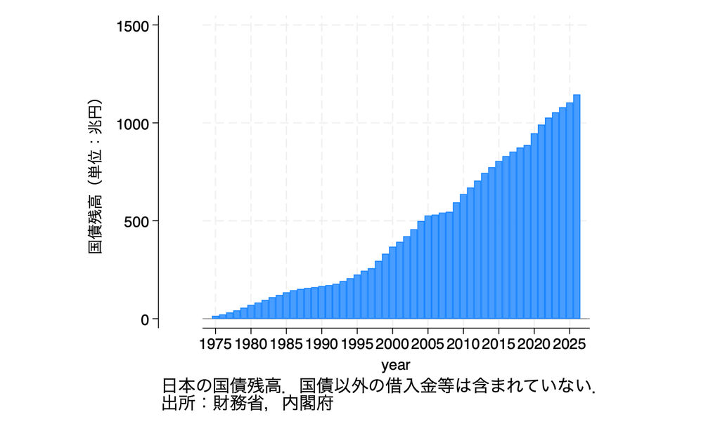

## 日本の$r$ vs $g$

- 2015年ごろまでの長期不景気は，低金利時代でも $r>g$ をもたらしていた様子．
  - データプロットは1995年度–2025年度
- 一方で，ここ10年程度は改善傾向
  - ただし，今後金利は上昇する見込み．

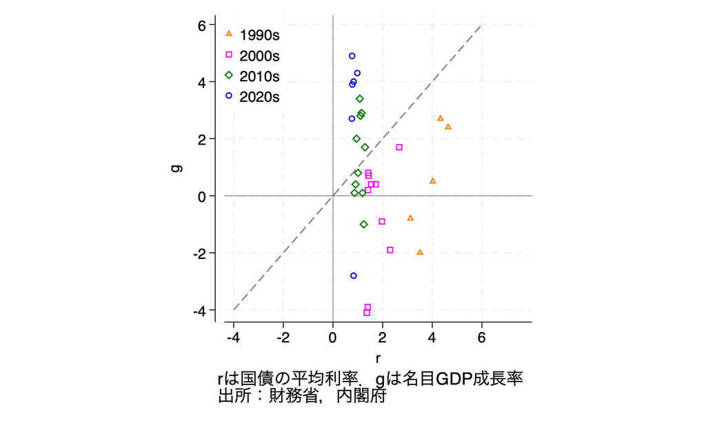

## 景気と金利

- ドーマー条件は**政府債務に対する金利**と経済成長率の関係．
  - 資産格差の問題として出る$r$ vs $g$とは少し違う文脈であることに注意．
    - こちらは**資本の収益率**と経済成長率の関係．
- ただし，資本の収益率増加をもたらす一般的な金利上昇と政府債務の金利はある程度相関を持つはず．
  - 金利上昇+成長率低下は政府のランニングコストに大きな影響を与えうる．
  - 金融政策は政府と独立に運用されるとされているが，借金が多い状況では利払いと持続可能性を考慮して，大胆な政策が難しくなりうる．
    - 実質的なホールドアップ状態．

財政状況が景気コントロールを制約しうる．

# 3 需要管理政策

## 公務員爆増計画

「需要をコントロールすることで不景気に応じることができる」

- 不景気なら公共セクターが失業者を雇い
  - 空き地に穴を掘らせてお金を埋める
  - 埋められたお金を掘り返す
  - 公債を財源にするならば需要は増加

失業者が公務員として活躍．

- 何が問題か？

## ルーカス批判

期待を反映していない政策はうまく機能しない可能性がある．

e.g.,

1. 財の供給能力に制約がある中で，今期の需要増加
2. 次期の物価上昇が予測される
3. 今期貯蓄を増やす意思決定
   - 需要は期待ほど上昇しない

## 公債の中立命題（リカードの等価定理）

2期間生存する家計の予算制約を考える．

- 家計の生涯所得の割引現在価値を$I=Y_1 + \frac{Y_2}{1+r}$とする．
- 政府が$G$だけの補助金を配ると考える．
- 税金$T$で財源調達
  - 生涯予算制約：$C_1 + \frac{C_2}{1+r} + T = I + G$
  - $T=G$なので，$C_1 + \frac{C_2}{1+r} = I$
- 公債で財源調達して補助金とする．将来徴税で償還．
  - 1期目の予算制約：$C_1 + S = Y_1 + G$
  - 2期目の予算制約：$C_2 + T = (1+r) S + Y_2$
    - 家計は将来の徴税$T=(1+r)G$を予測 -生涯予算制約：$C_1 + \frac{C_2}{1+r} = I$

## 期待のモデリング

生産性の期待，インフレ期待等，経済主体の期待を取り扱うモデル

DSGEフレームワークの整備：

- 実物景気循環モデル（Real Business Cycle model; RBC）
- ニューケインジアンモデル

講義の後半でざっくりとだけ触れます．

# 4 成長のためのインフラ整備

## インフラストラクチャー

ここでは，政府が整備するインフラストラクチャー（インフラ）として以下のものを想定．

- 道路
- 国防
- 社会保障
- 補助金制度，税制優遇制度
- その他，生産活動に影響を与えうる要因

政府は経済成長を後押しできるか？

## モデル

労働増大的技術進歩の生産関数からスタート．
$$Y_t = K_t^{\alpha} (A_t L)^{1-\alpha}$$

- 簡単化のため，人口成長なし（$L$：一定）を仮定している．

政府支出を$G_t$として，$A_t = G_t$と仮定する． 政府の公共支出が生産性に影響を与えるとする場合に，次のような生産関数が考えられる（Barro, 1990）．
$$Y_t = K_t^{\alpha} (G_t L)^{1-\alpha}$$

## 政府の予算制約

- 家計が税率$\tau$で所得に課税されているとする．
- 税収$T$は，$T_t = \tau Y_t$
- 政府の予算制約は$T_t=G_t$なので，
  $$G_t = \tau Y_t$$

## 均衡での生産関数

政府予算制約を生産関数に代入して整理すると，
$$Y_t = K_t (\tau L)^{\frac{1-\alpha}{\alpha}}$$

ここで，$(\tau L)^{\frac{1-\alpha}{\alpha}} \equiv B$とおけば，
$$Y_t = B K_t$$

AKモデルに帰着．

## 均斉成長経路

- 家計の可処分所得は$(1-\tau)Y_t$．
- 家計の貯蓄率が一定なら，資本蓄積方程式から
  $$g_K = s (1-\tau) B - \delta$$
- AKモデルなので，均斉成長経路上では$Y_t$と$K_t$の成長率が等しい（$g_Y = g_K$）．

結果的に，
$$g_Y = s (1-\tau) (\tau L)^{\frac{1-\alpha}{\alpha}} - \delta$$

## 最適課税

$g_Y$は閉じた形なので，$\tau$で微分して最適税率を計算できる．

- 一階の条件は，
  $$\frac{d g_Y}{d \tau} = \left( \frac{1-\alpha -\tau}{\alpha}\right) {s L^{\frac{1-\alpha}{\alpha}} \tau^{\frac{1-\alpha}{\alpha}-1}} = 0$$

ゆえに，
$$\tau = 1-\alpha$$

- 税率を公共支出の弾力性の値と等しくする．

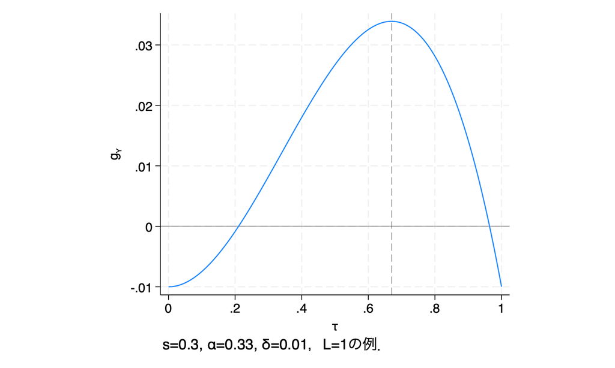

## Reference

- Barro, R. J. (1990) “Government Spending in a Simple Model of Endogeneous Growth,” *Journal of Political Economy*, 98.
- Bohn, H. (1998) “The behavior of U.S. public debt and deficits,” *Quarterly Journal of Economics*, 113.